# Lyme Disease Differential Gene Expression Re-Analysis

```
##
##
## #### INFLAMMATORY_RESPONSE
```

```
##
##
## #### TNFA_SIGNALING_VIA_NFKB
```

```
##
##
## #### INTERFERON_GAMMA_RESPONSE
```

```
##
##
## #### COMPLEMENT
```

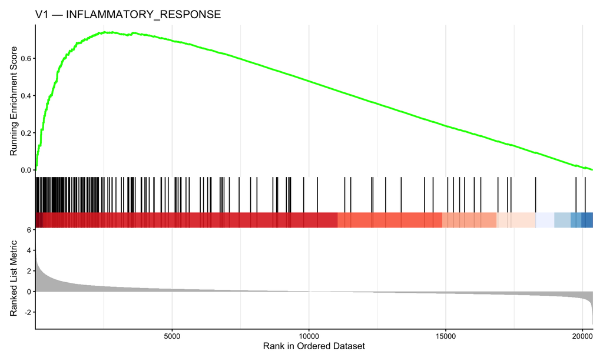

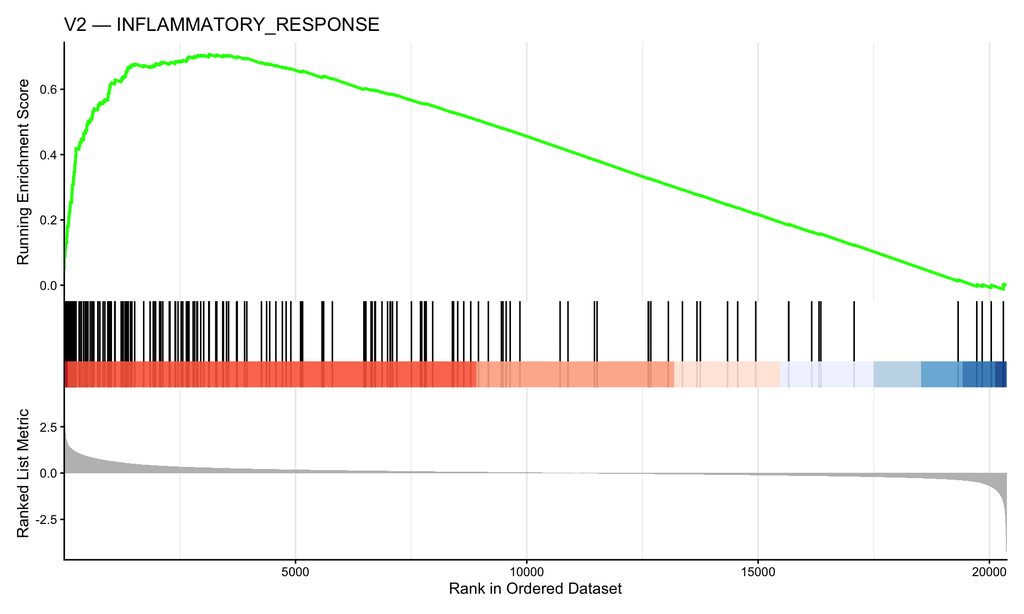

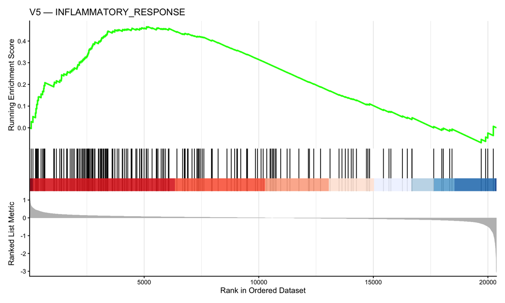

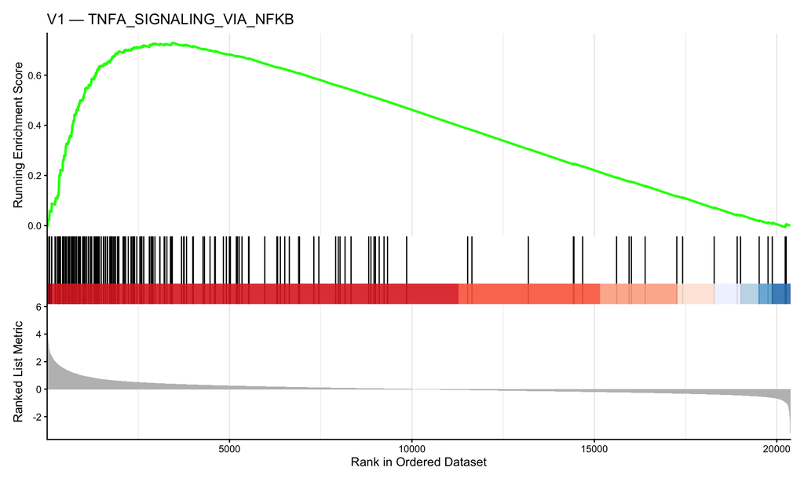

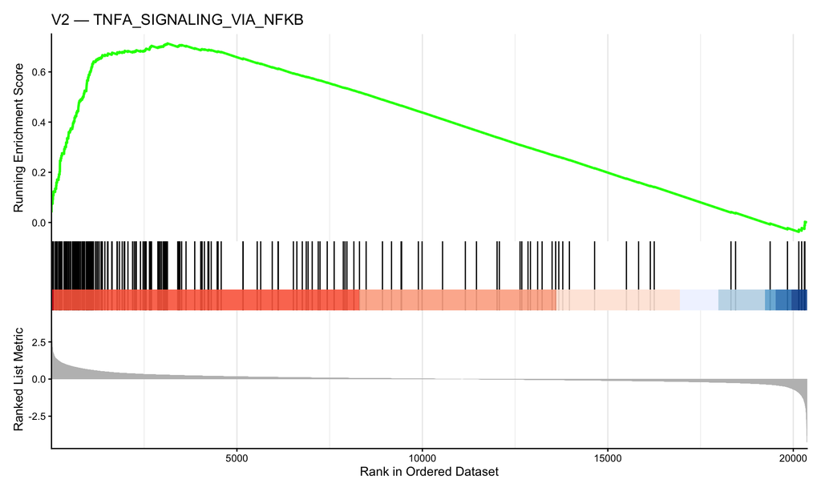

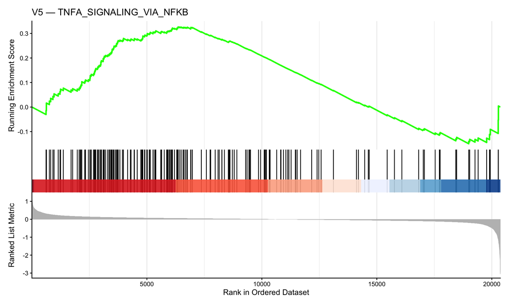

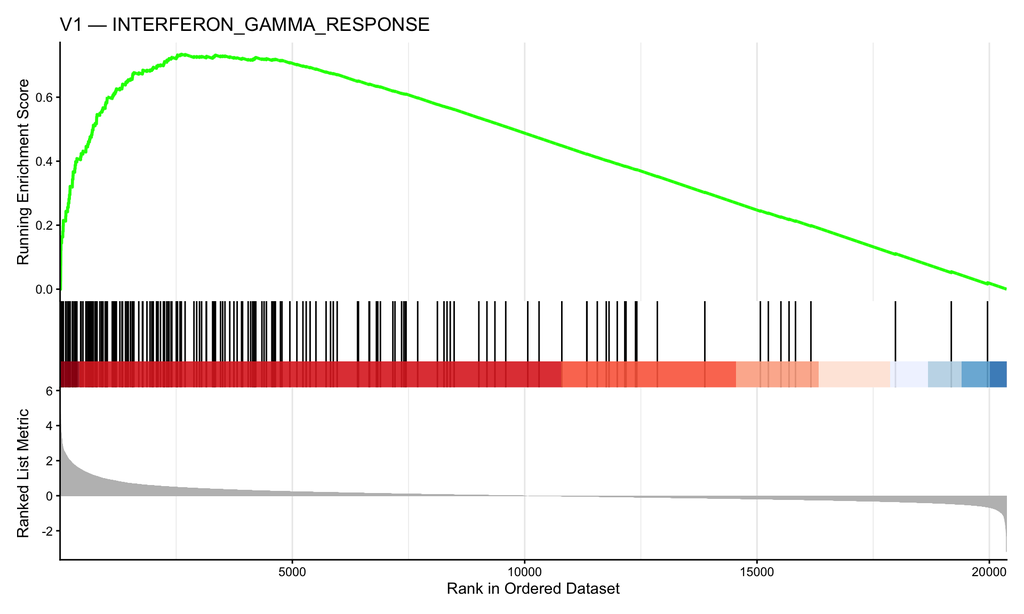

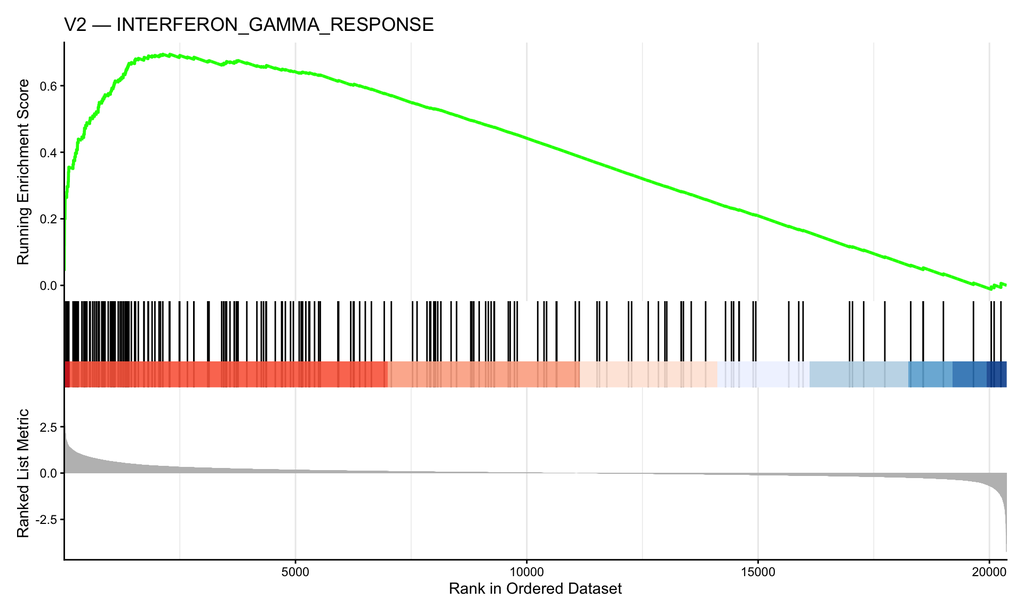

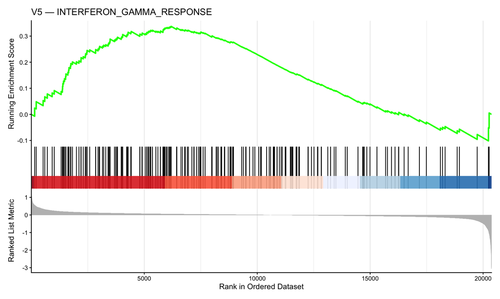

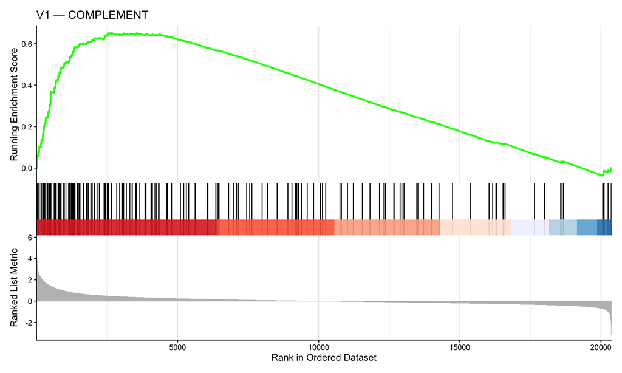

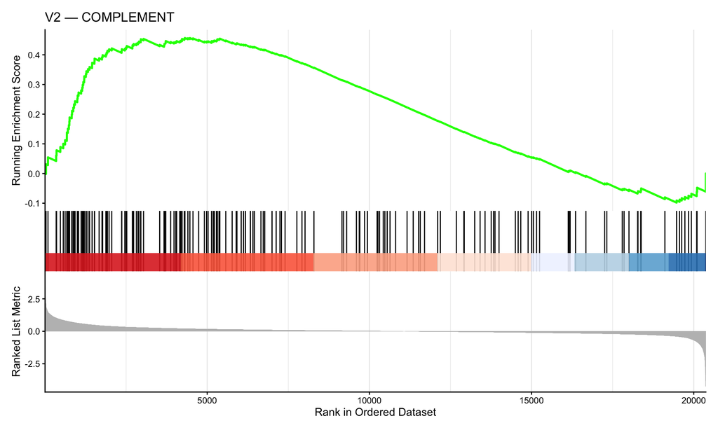

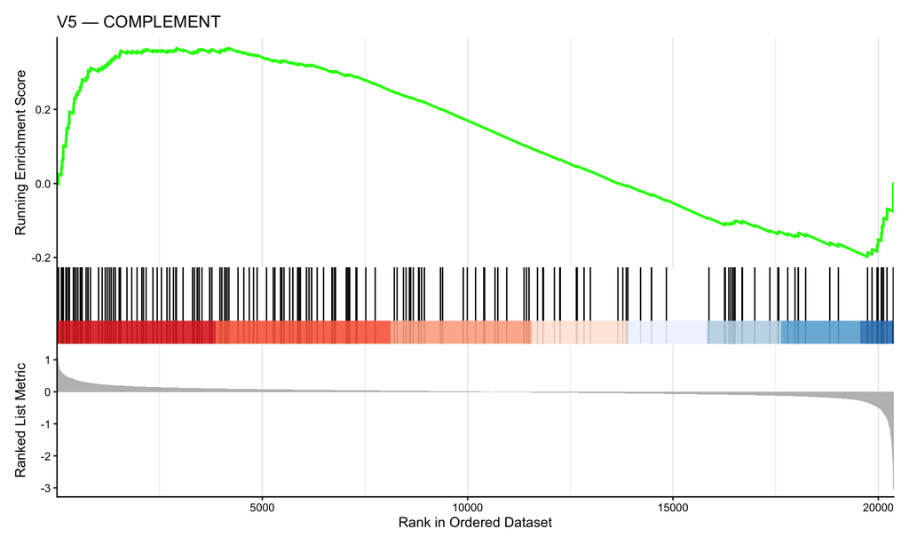

```r
key_pathways <- c("HALLMARK_INFLAMMATORY_RESPONSE",
                  "HALLMARK_TNFA_SIGNALING_VIA_NFKB",
                  "HALLMARK_INTERFERON_GAMMA_RESPONSE",
                  "HALLMARK_COMPLEMENT")

mountain_for <- function(g, pw, title) {
  df <- as.data.frame(g)
  if (!(pw %in% df$ID))
    return(ggplot() + theme_void() +
           ggtitle(paste0(title, "\n(", gsub("HALLMARK_", "", pw),
                          " not enriched here)")))
  gseaplot2(g, geneSetID = pw, title = paste0(title, " — ",
                                              gsub("HALLMARK_", "", pw)))
}

#for (pw in key_pathways) {
 # cat("\n\n#### ", gsub("HALLMARK_", "", pw), "\n\n", sep = "")
  #grid.arrange(
   # mountain_for(gsea_results$V1, pw, "V1"),
    #mountain_for(gsea_results$V2, pw, "V2"),
    #mountain_for(gsea_results$V5, pw, "V5"),
  #  ncol = 3
  #)
#}
for (pw in key_pathways) {
  cat("\n\n#### ", gsub("HALLMARK_", "", pw), "\n\n", sep = "")

  # Just print them. The chunk options out.width='32%' and fig.show='hold'
  # will automatically place them in a 3-column row!
  print(mountain_for(gsea_results$V1, pw, "V1"))
  print(mountain_for(gsea_results$V2, pw, "V2"))
  print(mountain_for(gsea_results$V5, pw, "V5"))
}
```

A high peak on the left = pathway genes pile up at the top of the ranked list (activated, in our LFC ranker that means upregulated). The peak typically gets lower and broader from V1 → V2 → V5; if the peak goes flat by V5, the pathway has fully resolved; if it stays sharp, the pathway is persistent, which is the canonical chronic / PTLDS-relevant biology.

## 12.4 GSEA NES heatmap — all Hallmarks across all visits

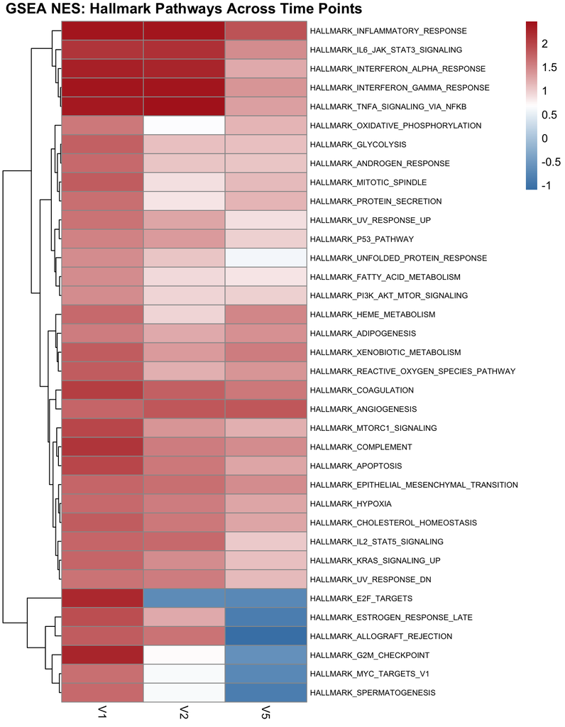

```r
nes_all <- lapply(names(gsea_results), function(tp) {
  as.data.frame(gsea_results[[tp]]) %>%
    dplyr::select(ID, NES, p.adjust) %>%
    dplyr::mutate(timepoint = tp)
}) %>% dplyr::bind_rows()

# Keep pathways significant in at least one time point
sig_any <- nes_all %>% dplyr::filter(p.adjust < 0.05) %>%
  dplyr::pull(ID) %>% unique()

if (length(sig_any) > 0) {
  nes_mat <- nes_all %>%
    dplyr::filter(ID %in% sig_any) %>%
    dplyr::select(ID, NES, timepoint) %>%
    tidyr::pivot_wider(names_from = timepoint, values_from = NES) %>%
    tibble::column_to_rownames("ID") %>% as.matrix()
  nes_mat[is.na(nes_mat)] <- 0
  nes_mat <- nes_mat[, intersect(c("V1","V2","V5"), colnames(nes_mat)), drop = FALSE]

  pheatmap(nes_mat,
           color = colorRampPalette(c("steelblue","white","firebrick"))(100),
           cluster_cols = FALSE,
           main = "GSEA NES: Hallmark Pathways Across Time Points",
           fontsize_row = 7)
}
```

This heatmap is the compact “everything at once” view. **Red** = activated, **blue** = suppressed. Pathways that remain red from V1 through V5 represent the **sustained signature** described in the paper. Pathways that fade to white by V5 indicate resolution. Compared to the per-visit dotplots above this heatmap is best for spotting *patterns of decay* (gradient from V1 to V5) rather than absolute amplitudes.

# 13. Biologic Theme Comparison

*Ref: Thomas’s book Ch. 8.4.2*

`compareCluster` from clusterProfiler directly compares enrichment results across multiple gene lists (our three time points), making the temporal dynamics visually clear.

### Why V5 was missing in the previous version of this plot

```r
gene_lists <- lapply(res_list, function(df) {
  df %>%
    dplyr::filter(!is.na(padj) & padj < 0.05 & abs(log2FoldChange) > 1 &
                  !is.na(Symbol) & Symbol != "") %>%
    dplyr::pull(Symbol) %>% unique()
})

cat("DEG-list sizes feeding compareCluster:\n")
```

```
## DEG-list sizes feeding compareCluster:
```

```r
for (tp in names(gene_lists))
  cat("  ", tp, ":", length(gene_lists[[tp]]), "genes\n")
```

```
##    V1 : 1020 genes
##    V2 : 549 genes
##    V5 : 125 genes
```

```r
# Count Hallmarks significant per visit at the strict cutoff
cat("\nHallmarks at padj<0.05 per visit (from Section 11.2 ora_hallmark_all):\n")
```

```
##
## Hallmarks at padj<0.05 per visit (from Section 11.2 ora_hallmark_all):
```

```r
for (tp in names(ora_hallmark_all))
  cat("  ", tp, ":", sum(as.data.frame(ora_hallmark_all[[tp]])$p.adjust < 0.05),
      "Hallmarks\n")
```

```
##    V1 : 9 Hallmarks
##    V2 : 6 Hallmarks
##    V5 : 0 Hallmarks
```

```r
cc_result <- compareCluster(
  geneClusters  = gene_lists,
  fun           = "enricher",
  TERM2GENE     = t2g_hallmark,
  pvalueCutoff  = 0.20,
  pAdjustMethod = "BH"
)

cc_df <- as.data.frame(cc_result)
cat("Visits represented in compareCluster output:\n")
```

```
## Visits represented in compareCluster output:
```

```r
print(table(cc_df$Cluster))
```

```
##
## V1 V2 V5
## 11 10  0
```

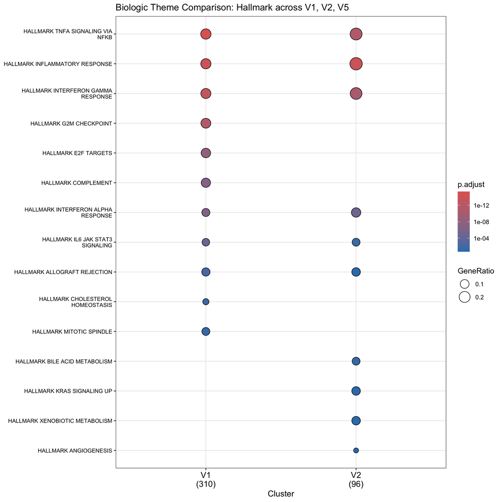

```r
if (nrow(cc_df) > 0)
  dotplot(cc_result, showCategory = 20) +
    ggtitle("Biologic Theme Comparison: Hallmark across V1, V2, V5") +
    theme(axis.text.x = element_text(angle = 0, hjust = 0.5),
          axis.text.y = element_text(size = 8))
```

# 14. 2nd Generation (cont.): GSVA (Gene Set Variation Analysis)

*Ref: Thomas’s book Ch. 8.1.2.2, 8.4.5; Hänzelmann et al. 2013*

GSVA completes the 2nd generation of pathway analysis. Unlike GSEA (which compares two groups), GSVA computes a **per-sample pathway score**. This preserves the full sample structure, so we can test pathway differences with standard linear models – exactly as Thomas describes in Ch. 8.4.5.

Think of it this way:

- **ORA** (1st gen): “Which pathways have too many DEGs?” (binary: gene is DE or not)
- **GSEA** (2nd gen-a): “Do pathway genes cluster at the top/bottom of the ranked list?” (uses fold-change magnitude, but still compares two groups)
- **GSVA** (2nd gen-b): “For each sample individually, how active is this pathway?” (produces a score per sample per pathway – then you can run any statistical model on those scores)

## 14.1 Prepare Gene Sets as Named Lists

GSVA needs gene sets as a named list of character vectors (gene symbols).

```r
hallmark_sets <- msigdb_hallmark %>%
  dplyr::select(gs_name, gene_symbol) %>%
  dplyr::group_by(gs_name) %>%
  dplyr::summarise(genes = list(unique(gene_symbol)), .groups = "drop") %>%
  tibble::deframe()

cat("Hallmark gene sets:", length(hallmark_sets), "\n")
```

```
## Hallmark gene sets: 50
```

```r
cat("Example set sizes:", head(sapply(hallmark_sets, length)), "\n")
```

```
## Example set sizes: 200 200 101 36 200 44
```

## 14.2 Prepare Expression Matrix with Gene Symbols

GSVA needs the matrix rows to be gene symbols (matching the gene sets), not Entrez IDs.

```r
# Use VST-normalised data for GSVA (Gaussian kernel, Ch. 8.4.5)
vst_mat <- assay(vsd)

# Map Entrez IDs to Symbols
symbol_map <- gene_annot$Symbol[match(as.numeric(rownames(vst_mat)),
                                       gene_annot$GeneID)]

# Keep only rows with valid symbols, handle duplicates by keeping highest mean
keep_sym <- !is.na(symbol_map) & symbol_map != ""
vst_sym  <- vst_mat[keep_sym, ]
rownames(vst_sym) <- symbol_map[keep_sym]

# Remove duplicate gene symbols (keep the one with highest mean expression)
dup_idx <- duplicated(rownames(vst_sym))
vst_sym <- vst_sym[!dup_idx, ]

cat("GSVA input matrix:", nrow(vst_sym), "genes x", ncol(vst_sym), "samples\n")
```

```
## GSVA input matrix: 20374 genes x 75 samples
```

## 14.3 Run GSVA

```r
gsva_param <- gsvaParam(
  exprData = vst_sym,
  geneSets = hallmark_sets,
  kcdf     = "Gaussian",   # Gaussian for continuous (VST) data; Poisson for counts
  maxDiff  = TRUE
)

gsva_scores <- gsva(gsva_param)

cat("GSVA output:", nrow(gsva_scores), "pathways x", ncol(gsva_scores), "samples\n")
```

```
## GSVA output: 50 pathways x 75 samples
```

## 14.4 GSVA Heatmap

Each cell shows how active a pathway is in a given sample (relative to other samples). This reveals the per-patient, per-time-point pathway landscape.

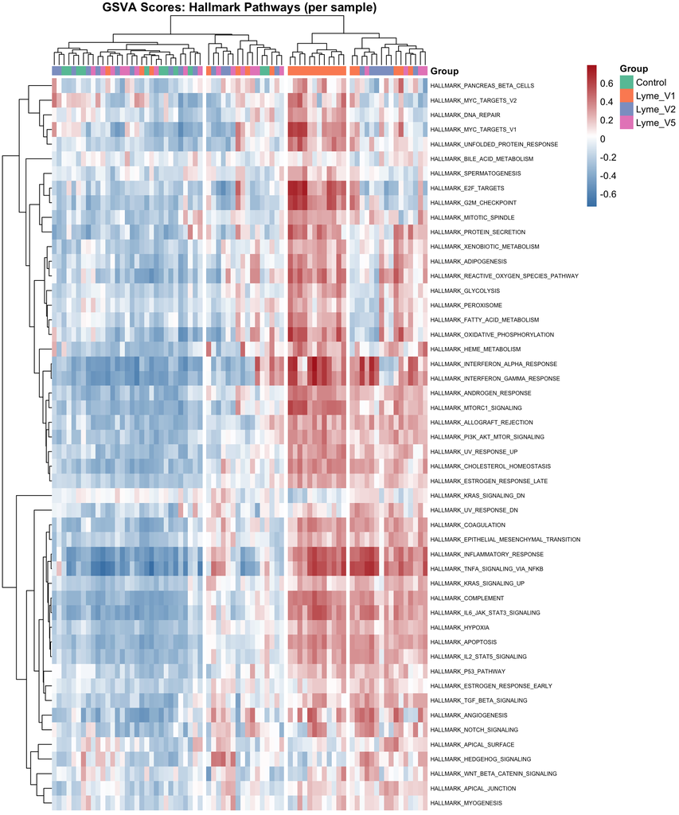

```r
pheatmap(gsva_scores,
         annotation_col = row_annot,
         annotation_colors = ann_colors,
         show_colnames = FALSE,
         fontsize_row = 6,
         color = colorRampPalette(c("steelblue", "white", "firebrick"))(100),
         main = "GSVA Scores: Hallmark Pathways (per sample)",
         clustering_distance_rows = "correlation",
         cutree_cols = 4)
```

The key advantage of GSVA over GSEA: you can see individual patient variation. Some V5 patients may still have highly activated inflammatory pathways (potential PTLDS candidates), while others return to control-like levels.

## 14.5 Test GSVA Scores Between Groups

Following Thomas’s Ch. 8.4.5: since GSVA scores are continuous values per sample, we can use a standard linear model (limma) to test which pathways differ significantly between groups. This mirrors the workflow from Ch. 7.5.1.

```r
library(limma)

design_gsva <- model.matrix(~ 0 + group, data = annot)
colnames(design_gsva) <- levels(annot$group)

# Fit linear model to GSVA scores (instead of gene expression)
fit_gsva <- lmFit(gsva_scores, design_gsva)

# Define contrasts (same comparisons as DESeq2)
contrast_mat <- makeContrasts(
  V1_vs_Ctrl = Lyme_V1 - Control,
  V2_vs_Ctrl = Lyme_V2 - Control,
  V5_vs_Ctrl = Lyme_V5 - Control,
  levels = design_gsva
)

fit_gsva2 <- contrasts.fit(fit_gsva, contrast_mat) %>% eBayes()
```

```r
gsva_results_list <- list()
for (coef_name in colnames(contrast_mat)) {
  tt <- topTable(fit_gsva2, coef = coef_name, number = Inf) %>%
    tibble::rownames_to_column("pathway")
  gsva_results_list[[coef_name]] <- tt

  n_sig <- sum(tt$adj.P.Val < 0.05)
  cat(coef_name, ":", n_sig, "pathways with adj.P.Val < 0.05\n")
}
```

```
## V1_vs_Ctrl : 43 pathways with adj.P.Val < 0.05
## V2_vs_Ctrl : 0 pathways with adj.P.Val < 0.05
## V5_vs_Ctrl : 0 pathways with adj.P.Val < 0.05
```

## 14.6 GSVA Volcano-Style Plot

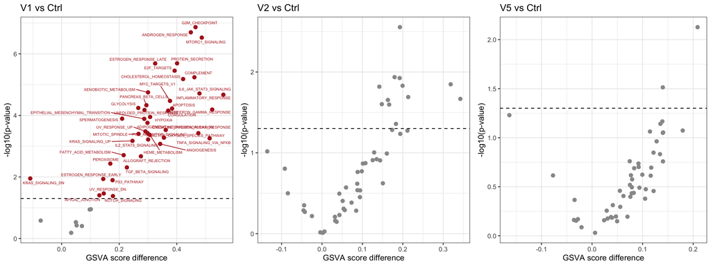

```r
gsva_volcano_plots <- lapply(names(gsva_results_list), function(nm) {
  df <- gsva_results_list[[nm]] %>%
    dplyr::mutate(
      sig = ifelse(adj.P.Val < 0.05, "Significant", "NS"),
      label = ifelse(adj.P.Val < 0.05,
                     gsub("HALLMARK_", "", pathway), NA)
    )
  ggplot(df, aes(x = logFC, y = -log10(P.Value), color = sig)) +
    geom_point(size = 2.5) +
    scale_color_manual(values = c(Significant = "firebrick", NS = "gray60")) +
    geom_text_repel(aes(label = label), size = 2.2, max.overlaps = 20,
                    na.rm = TRUE) +
    geom_hline(yintercept = -log10(0.05), linetype = "dashed") +
    labs(title = gsub("_", " ", nm),
         x = "GSVA score difference", y = "-log10(p-value)") +
    theme(legend.position = "none")
})

grid.arrange(grobs = gsva_volcano_plots, ncol = 3)
```

Each dot is a Hallmark pathway. The x-axis is the difference in GSVA score between Lyme and Control (positive = more active in Lyme). Labeled pathways are significant (adj.P.Val < 0.05). Compare the three panels: V1 should have the most extreme differences, V5 the least – mirroring the gene-level DEG pattern.

## 14.7 GSVA Score Boxplots for Key Pathways

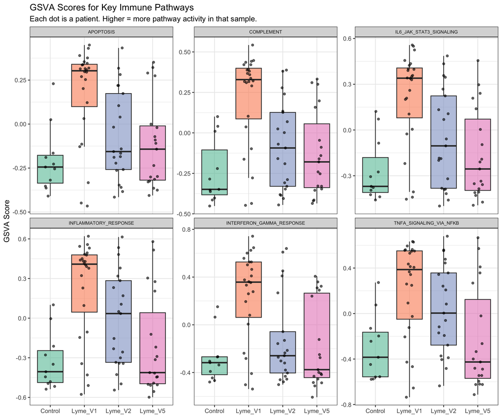

```r
key_pw <- c("HALLMARK_INFLAMMATORY_RESPONSE",
            "HALLMARK_TNFA_SIGNALING_VIA_NFKB",
            "HALLMARK_INTERFERON_GAMMA_RESPONSE",
            "HALLMARK_COMPLEMENT",
            "HALLMARK_IL6_JAK_STAT3_SIGNALING",
            "HALLMARK_APOPTOSIS")

gsva_long <- gsva_scores[rownames(gsva_scores) %in% key_pw, ] %>%
  as.data.frame() %>%
  tibble::rownames_to_column("pathway") %>%
  tidyr::pivot_longer(-pathway, names_to = "GSM", values_to = "score") %>%
  dplyr::left_join(annot %>% dplyr::select(GSM, group, visit), by = "GSM") %>%
  dplyr::mutate(pathway = gsub("HALLMARK_", "", pathway))

ggplot(gsva_long, aes(x = group, y = score, fill = group)) +
  geom_boxplot(alpha = 0.6, outlier.shape = NA) +
  geom_jitter(width = 0.15, size = 1.5, alpha = 0.6) +
  facet_wrap(~ pathway, scales = "free_y", ncol = 3) +
  scale_fill_brewer(palette = "Set2") +
  labs(title = "GSVA Scores for Key Immune Pathways",
       subtitle = "Each dot is a patient. Higher = more pathway activity in that sample.",
       x = NULL, y = "GSVA Score") +
  theme(legend.position = "none",
        strip.text = element_text(size = 8))
```

These boxplots are the unique output of GSVA that neither ORA nor GSEA can produce. Each dot is an individual patient’s pathway activity. Look for:

- **V1 >> Control**: Pathway is activated during acute infection (expected for immune/inflammatory pathways).
- **V2 still elevated**: Pathway stays active even after antibiotic treatment, evidence for the sustained signature.
- **V5 approaching Control**: Pathway is resolving (good sign for most patients).
- **V5 patients still elevated**: These outlier dots may correspond to patients with persistent symptoms (PTLDS).

This connects directly to the paper’s central finding: the gene expression signature of Lyme disease persists after treatment. GSVA lets us see this at the **individual patient level**, which the original study’s bulk comparisons could not show.

# 15. Third Generation: SPIA (topology-aware KEGG perturbation)

*Ref: Khatri et al. 2012 (three generations); Tarca et al. 2009; Thomas’s book Ch. 8 — pathway topology*

First-generation ORA asks whether a pathway contains more DEG labels than expected. Second-generation GSEA/GSVA uses ranked scores or per-sample enrichment without explicit *wiring* between genes. **Signalling Pathway Impact Analysis (SPIA)** adds a *perturbation* term: it walks curated **KEGG** signalling topology so that genes upstream/downstream and activation vs inhibition relations contribute differently from a flat hypergeometric count. The combined evidence (over-representation **pNDE** + topology **pPERT**) yields a global **pG** (and FDR-style **pGFdr**).

### Should we trust SPIA for this course project?

SPIA is pedagogically valuable: it makes the “topology” idea concrete and produces interpretable **Activated / Inhibited** status per pathway. For a *scientific* discussion with your professor, consider these limitations:

- **Database scope:** SPIA is tied to **KEGG** pathway maps (not MSigDB Hallmark). Immune–infection biology is only partially captured; many Lyme-relevant processes appear in Hallmark/GO instead.
- **Model assumptions:** Edge signs and “perturbation accumulation” are approximations; real immune networks are context- and cell-type–specific.
- **Redundancy:** Top SPIA hits may overlap messages already seen in ORA/GSEA/GSVA — agreement strengthens evidence; disagreement invites caution, not automatic dismissal.
- **Licensing / maintenance:** KEGG data are periodically updated; results can shift slightly between SPIA/database versions.

We run SPIA **anyway** so you can compare outputs side-by-side with first- and second-generation results and document the workflow.

## 15.1 Prepare DE vectors (Entrez) and run SPIA

SPIA expects a **named numeric vector of log2 fold changes for differentially expressed genes** (Entrez IDs as names) and the **universe** of all Entrez IDs tested (`rownames(dds)`).

```r
spia_from_res <- function(res_df, dds_obj) {
  sig <- res_df %>%
    dplyr::filter(!is.na(padj), padj < 0.05, !is.na(log2FoldChange)) %>%
    dplyr::mutate(GeneID = as.character(GeneID))
  if (nrow(sig) < 5)
    return(NULL)
  # one value per Entrez: keep strongest |LFC| if duplicates exist
  sig <- sig %>%
    dplyr::group_by(GeneID) %>%
    dplyr::slice_max(order_by = abs(log2FoldChange), n = 1, with_ties = FALSE) %>%
    dplyr::ungroup()
  de <- sig$log2FoldChange
  names(de) <- sig$GeneID
  all_ids <- as.character(rownames(dds_obj))
  spia(de, all_ids, organism = "hsa", nB = 2000, verbose = FALSE)
}

spia_v1 <- spia_from_res(res_list$V1, dds)
spia_v2 <- spia_from_res(res_list$V2, dds)
spia_v5 <- spia_from_res(res_list$V5, dds)
```

## 15.2 Top KEGG pathways (global pG)

```r
fmt_spia <- function(x, n = 12) {
  if (is.null(x) || nrow(x) == 0)
    return(invisible(NULL))
  tibble::rownames_to_column(as.data.frame(x), "pathway_id") %>%
    dplyr::arrange(pG) %>%
    dplyr::select(Name, ID, Status, pNDE, pPERT, pG, pGFdr) %>%
    head(n)
}

fmt_spia(spia_v1)
```

```
##                                           Name    ID    Status         pNDE    pPERT           pG        pGFdr
## 1                  Chemokine signaling pathway 04062 Activated 3.359581e-05 0.000005 3.948714e-09 5.409738e-07
## 2       Cytokine-cytokine receptor interaction 04060 Activated 1.068794e-03 0.000005 1.071322e-07 7.338553e-06
## 3                                 Tuberculosis 05152 Activated 1.991533e-05 0.001000 3.730495e-07 1.703593e-05
## 4              Staphylococcus aureus infection 05150 Activated 1.187504e-02 0.000005 1.047342e-06 3.587148e-05
## 5  Protein processing in endoplasmic reticulum 04141 Activated 9.124461e-08 0.891000 1.408515e-06 3.859331e-05
## 6                 Systemic lupus erythematosus 05322 Activated 2.902366e-02 0.000005 2.430110e-06 5.548751e-05
## 7                                Legionellosis 05134 Activated 1.571839e-05 0.031000 7.569473e-06 1.481454e-04
## 8                                     Lysosome 04142 Inhibited 6.075784e-07 1.000000 9.304325e-06 1.593366e-04
## 9                                       Asthma 05310 Inhibited 6.810648e-01 0.000005 4.627893e-05 7.044682e-04
## 10                        Salmonella infection 05132 Activated 2.169491e-04 0.023000 6.590619e-05 9.029149e-04
## 11                NF-kappa B signaling pathway 04064 Activated 1.517219e-05 0.431000 8.460234e-05 1.053684e-03
## 12                                  Cell cycle 04110 Inhibited 3.076625e-05 0.266000 1.040438e-04 1.187834e-03
```

```r
fmt_spia(spia_v2)
```

```
##                                      Name    ID    Status         pNDE    pPERT           pG        pGFdr
## 1  Cytokine-cytokine receptor interaction 04060 Activated 1.312621e-02 0.000005 1.151117e-06 0.0001194957
## 2             Chemokine signaling pathway 04062 Activated 2.040543e-02 0.000005 1.744463e-06 0.0001194957
## 3                             Influenza A 05164 Activated 2.628495e-07 0.987000 4.193666e-06 0.0001915108
## 4                                  Asthma 05310 Inhibited 6.175368e-01 0.000005 4.226450e-05 0.0014298974
## 5              Autoimmune thyroid disease 05320 Inhibited 7.753980e-01 0.000005 5.218603e-05 0.0014298974
## 6                                 Measles 05162 Activated 3.266501e-05 0.277000 1.141245e-04 0.0026058435
## 7            NF-kappa B signaling pathway 04064 Activated 9.659101e-05 0.526000 5.531587e-04 0.0108261069
## 8              Jak-STAT signaling pathway 04630 Inhibited 9.219481e-05 0.816000 7.895450e-04 0.0135209582
## 9                Herpes simplex infection 05168 Activated 3.719641e-04 0.435000 1.574215e-03 0.0239630476
## 10          Cytosolic DNA-sensing pathway 04623 Activated 1.022284e-03 0.394000 3.551360e-03 0.0486536291
## 11                            Hepatitis C 05160 Inhibited 8.577777e-04 0.693000 5.009875e-03 0.0565231912
## 12           Epstein-Barr virus infection 05169 Activated 4.229892e-03 0.159000 5.585168e-03 0.0565231912
```

```r
fmt_spia(spia_v5)
```

```
##                                            Name    ID    Status       pNDE pPERT          pG     pGFdr
## 1                                        Asthma 05310 Inhibited 0.46416317 0.001 0.004026743 0.3540310
## 2                           Allograft rejection 05330 Inhibited 0.65362349 0.001 0.005446631 0.3540310
## 3                    Autoimmune thyroid disease 05320 Inhibited 0.65362349 0.007 0.029223168 0.9999985
## 4  Intestinal immune network for IgA production 04672 Inhibited 0.72632933 0.008 0.035724162 0.9999985
## 5                            Taste transduction 04742 Activated 0.85553786 0.016 0.072429035 0.9999985
## 6                                      Lysosome 04142 Inhibited 0.01497052 1.000 0.077871745 0.9999985
## 7                             Pancreatic cancer 05212 Inhibited 0.62300502 0.026 0.082980746 0.9999985
## 8                           Cholinergic synapse 04725 Inhibited 0.61610556 0.030 0.092247543 0.9999985
## 9                             Colorectal cancer 05210 Inhibited 0.56002289 0.035 0.096674774 0.9999985
## 10                       PPAR signaling pathway 03320 Inhibited 0.60611152 0.033 0.098247033 0.9999985
## 11                   Jak-STAT signaling pathway 04630 Activated 0.02824928 0.736 0.101321241 0.9999985
## 12                          Parkinson's disease 05012 Inhibited 0.02108182 1.000 0.102443834 0.9999985
```

## 15.3 Visualise top SPIA hits across V1, V2, V5

For every visit we show the top-15 KEGG pathways (by global pG) as a horizontal bar plot, coloured by SPIA’s `Status` (Activated / Inhibited / Mixed). Comparing the three panels gives the SPIA-equivalent of the GSEA NES heatmap: which KEGG signalling maps stay activated through V2 / V5, which fade.

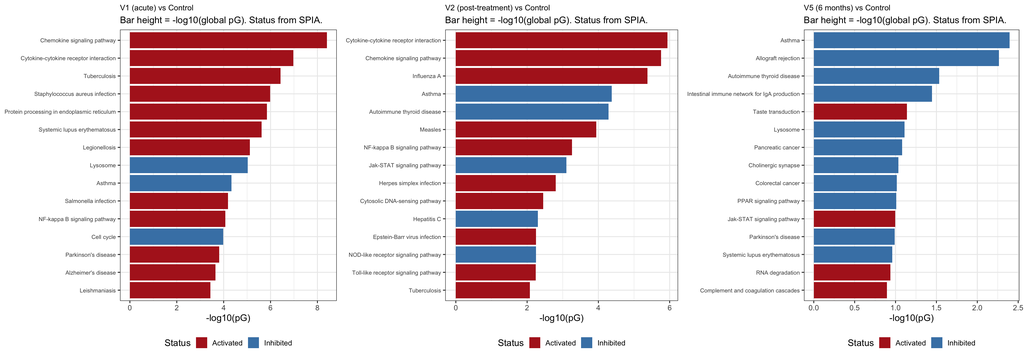

```r
plot_spia_top <- function(s, title, n = 15) {
  if (is.null(s) || nrow(s) == 0)
    return(ggplot() + theme_void() +
           ggtitle(paste(title, "\n(no SPIA results — too few DEGs at padj<0.05)")))
  top <- tibble::rownames_to_column(as.data.frame(s), "pathway_id") %>%
    dplyr::arrange(pG) %>%
    head(n)
  ggplot(top, aes(x = reorder(Name, -log10(pG)),
                  y = -log10(pG), fill = Status)) +
    geom_col() + coord_flip() +
    scale_fill_manual(values = c(Activated = "firebrick",
                                 Inhibited = "steelblue",
                                 Mixed = "gray50"),
                      na.value = "gray70") +
    labs(title = title,
         subtitle = "Bar height = -log10(global pG). Status from SPIA.",
         x = NULL, y = "-log10(pG)") +
    theme(legend.position = "bottom",
          axis.text.y = element_text(size = 8),
          plot.title  = element_text(size = 11))
}

grid.arrange(
  plot_spia_top(spia_v1, "V1 (acute) vs Control"),
  plot_spia_top(spia_v2, "V2 (post-treatment) vs Control"),
  plot_spia_top(spia_v5, "V5 (6 months) vs Control"),
  ncol = 3
)
```

## 15.4 Does SPIA agree with the Hallmark / GO results? (cross-database validation)

**Short answer:** SPIA uses a *different reference database* (KEGG signalling maps) than ORA/GSEA/GSVA in Sections 11–14 (which use **MSigDB Hallmark** + **GO:BP**). Pathway *names* therefore do not match 1-to-1 — but we can still check whether the same biological signal is captured by all three databases.

### Why a direct name-match doesn’t work

| Database | Source | Granularity | Used by |
| --- | --- | --- | --- |
| **MSigDB Hallmark** | Liberzon *et al.* 2015, 50 curated, low-redundancy gene sets | broad biological themes (~200 genes / set) | ORA, GSEA, GSVA in Sections 11–14 |
| **GO:BP** | Gene Ontology Consortium | thousands of overlapping terms | ORA in Section 11.3 |
| **KEGG signalling maps** | Kanehisa Lab | ~330 curated pathways with **edges** (activation/inhibition) | SPIA in this section |

There is overlap *in the underlying biology* (e.g. “Cytokine-cytokine receptor interaction” in KEGG ↔︎ `HALLMARK_INFLAMMATORY_RESPONSE`) but the gene sets are not identical, KEGG is more mechanistic and signalling-focused, Hallmark is more thematic.

### Strategy

The cleanest validation is **same database, multiple methods**: run **ORA-KEGG** and **GSEA-KEGG** on V1 using KEGG gene sets pulled from MSigDB, then compare to **SPIA**. Any disagreement is then *methodological* (topology vs. flat enrichment), not *database-driven*. We then add a **gene-level** overlap with the Hallmark leading edge to bridge to Sections 11–12.

### 15.4.1 Pull KEGG gene sets from MSigDB

```r
msigdb_kegg <- msigdbr(species = "Homo sapiens", collection = "C2") %>%
  dplyr::filter(grepl("^KEGG_", gs_name))

cat("KEGG gene sets pulled from MSigDB:",
    length(unique(msigdb_kegg$gs_name)), "pathways\n")
```

```
## KEGG gene sets pulled from MSigDB: 844 pathways
```

```r
t2g_kegg <- msigdb_kegg %>% dplyr::select(gs_name, gene_symbol)
```

### 15.4.2 KEGG ORA + KEGG GSEA at every visit

```r
ora_kegg_all  <- list()
gsea_kegg_all <- list()
for (tp in names(res_list)) {
  ora_kegg_all[[tp]] <- enricher(
    gene         = sig_sym_per_tp[[tp]],
    universe     = univ_sym_per_tp[[tp]],
    TERM2GENE    = t2g_kegg,
    pvalueCutoff = 1, pAdjustMethod = "BH", qvalueCutoff = 1
  )
  gsea_kegg_all[[tp]] <- GSEA(
    geneList     = ranked_lists[[tp]],
    TERM2GENE    = t2g_kegg,
    pvalueCutoff = 1, eps = 0
  )
}

# Backward-compat aliases
ora_kegg_v1  <- ora_kegg_all$V1
gsea_kegg_v1 <- gsea_kegg_all$V1

for (tp in names(res_list)) {
  cat(tp,
      "  KEGG-ORA  sig (padj<0.05):",
      sum(as.data.frame(ora_kegg_all[[tp]])$p.adjust  < 0.05),
      "  KEGG-GSEA sig (padj<0.05):",
      sum(as.data.frame(gsea_kegg_all[[tp]])$p.adjust < 0.05), "\n")
}
```

```
## V1   KEGG-ORA  sig (padj<0.05): 12   KEGG-GSEA sig (padj<0.05): 50
## V2   KEGG-ORA  sig (padj<0.05): 1   KEGG-GSEA sig (padj<0.05): 9
## V5   KEGG-ORA  sig (padj<0.05): 0   KEGG-GSEA sig (padj<0.05): 0
```

### 15.4.3 Map SPIA → MSigDB-KEGG and merge — for each visit

SPIA exposes the human-readable pathway name (e.g. `"Cytokine-cytokine receptor interaction"`), MSigDB exposes the upper-snake-case `gs_name` (e.g. `"KEGG_CYTOKINE_CYTOKINE_RECEPTOR_INTERACTION"`). We normalise both, join, and produce a per-visit `cross_kegg_<tp>` table.

```r
norm_kegg_name <- function(s) {
  s <- toupper(s); s <- gsub("[^A-Z0-9]+", "_", s)
  gsub("^_+|_+$", "", s)
}

build_cross <- function(spia_obj, ora_obj, gsea_obj) {
  if (is.null(spia_obj) || nrow(spia_obj) == 0) return(NULL)
  spia_df <- tibble::rownames_to_column(as.data.frame(spia_obj), "spia_pwid") %>%
    dplyr::transmute(spia_pwid,
                     pathway_name = Name,
                     norm         = norm_kegg_name(Name),
                     spia_status  = Status,
                     spia_pG      = pG,
                     spia_pGFdr   = pGFdr)
  ora_df  <- as.data.frame(ora_obj) %>%
    dplyr::transmute(norm = sub("^KEGG_", "", ID),
                     ora_padj  = p.adjust,
                     ora_count = Count)
  gsea_df <- as.data.frame(gsea_obj) %>%
    dplyr::transmute(norm = sub("^KEGG_", "", ID),
                     gsea_padj = p.adjust,
                     gsea_NES  = NES)
  spia_df %>%
    dplyr::left_join(ora_df,  by = "norm") %>%
    dplyr::left_join(gsea_df, by = "norm")
}

cross_kegg_list <- list(
  V1 = build_cross(spia_v1, ora_kegg_all$V1, gsea_kegg_all$V1),
  V2 = build_cross(spia_v2, ora_kegg_all$V2, gsea_kegg_all$V2),
  V5 = build_cross(spia_v5, ora_kegg_all$V5, gsea_kegg_all$V5)
)

# Backward-compat alias
cross_kegg <- cross_kegg_list$V1

for (tp in names(cross_kegg_list)) {
  ck <- cross_kegg_list[[tp]]
  if (is.null(ck)) {
    cat(tp, ": no SPIA results to map.\n"); next
  }
  cat(tp, ": SPIA pathways successfully mapped to MSigDB KEGG:",
      sum(!is.na(ck$gsea_padj) | !is.na(ck$ora_padj)),
      "/", nrow(ck), "\n")
}
```

```
## V1 : SPIA pathways successfully mapped to MSigDB KEGG: 87 / 137
## V2 : SPIA pathways successfully mapped to MSigDB KEGG: 87 / 137
## V5 : SPIA pathways successfully mapped to MSigDB KEGG: 82 / 130
```

```r
fmt_cross <- function(ck, n = 10) {
  if (is.null(ck) || nrow(ck) == 0) return(NULL)
  ck %>%
    dplyr::arrange(spia_pG) %>%
    dplyr::mutate(
      spia_pG    = signif(spia_pG, 2),
      spia_pGFdr = signif(spia_pGFdr, 2),
      ora_padj   = signif(ora_padj, 2),
      gsea_padj  = signif(gsea_padj, 2),
      gsea_NES   = round(gsea_NES, 2)
    ) %>%
    dplyr::select(pathway_name, spia_status,
                  spia_pG, spia_pGFdr,
                  ora_padj, ora_count,
                  gsea_NES, gsea_padj) %>%
    head(n)
}

for (tp in names(cross_kegg_list)) {
  cat("\n\n#### Top 10 SPIA pathways at ", tp, " — with KEGG-ORA & KEGG-GSEA evidence\n\n", sep = "")
  tab <- fmt_cross(cross_kegg_list[[tp]], 10)
  if (is.null(tab)) {
    cat("_No SPIA results at this visit._\n")
  } else {
    print(knitr::kable(tab, row.names = FALSE))
  }
}
```

#### Top 10 SPIA pathways at V1 — with KEGG-ORA & KEGG-GSEA evidence

| pathway_name | spia_status | spia_pG | spia_pGFdr | ora_padj | ora_count | gsea_NES | gsea_padj |
| --- | --- | --- | --- | --- | --- | --- | --- |
| Chemokine signaling pathway | Activated | 0.0e+00 | 5.0e-07 | 1.0e-01 | 18 | 1.91 | 1.9e-06 |
| Cytokine-cytokine receptor interaction | Activated | 1.0e-07 | 7.3e-06 | 2.5e-05 | 31 | 1.90 | 6.0e-07 |
| Tuberculosis | Activated | 4.0e-07 | 1.7e-05 | NA | NA | NA | NA |
| Staphylococcus aureus infection | Activated | 1.0e-06 | 3.6e-05 | NA | NA | NA | NA |
| Protein processing in endoplasmic reticulum | Activated | 1.4e-06 | 3.9e-05 | NA | NA | NA | NA |
| Systemic lupus erythematosus | Activated | 2.4e-06 | 5.5e-05 | 1.8e-01 | 11 | 1.96 | 7.0e-05 |
| Legionellosis | Activated | 7.6e-06 | 1.5e-04 | NA | NA | NA | NA |
| Lysosome | Inhibited | 9.3e-06 | 1.6e-04 | 6.7e-01 | 10 | 1.63 | 7.0e-03 |
| Asthma | Inhibited | 4.6e-05 | 7.0e-04 | 4.5e-01 | 4 | 0.94 | 7.5e-01 |
| Salmonella infection | Activated | 6.6e-05 | 9.0e-04 | NA | NA | NA | NA |

#### Top 10 SPIA pathways at V2 — with KEGG-ORA & KEGG-GSEA evidence

| pathway_name | spia_status | spia_pG | spia_pGFdr | ora_padj | ora_count | gsea_NES | gsea_padj |
| --- | --- | --- | --- | --- | --- | --- | --- |
| Cytokine-cytokine receptor interaction | Activated | 1.2e-06 | 0.00012 | 0.0011 | 15 | 2.02 | 2.0e-07 |
| Chemokine signaling pathway | Activated | 1.7e-06 | 0.00012 | 0.3300 | 8 | 1.91 | 4.0e-05 |
| Influenza A | Activated | 4.2e-06 | 0.00019 | NA | NA | NA | NA |
| Asthma | Inhibited | 4.2e-05 | 0.00140 | 0.4300 | 2 | -1.17 | 9.8e-01 |
| Autoimmune thyroid disease | Inhibited | 5.2e-05 | 0.00140 | 0.6100 | 1 | -1.31 | 9.8e-01 |
| Measles | Activated | 1.1e-04 | 0.00260 | NA | NA | NA | NA |
| NF-kappa B signaling pathway | Activated | 5.5e-04 | 0.01100 | NA | NA | NA | NA |
| Jak-STAT signaling pathway | Inhibited | 7.9e-04 | 0.01400 | 0.3300 | 6 | 1.25 | 9.8e-01 |
| Herpes simplex infection | Activated | 1.6e-03 | 0.02400 | NA | NA | NA | NA |
| Cytosolic DNA-sensing pathway | Activated | 3.6e-03 | 0.04900 | 0.4700 | 2 | 1.93 | 2.8e-03 |

#### Top 10 SPIA pathways at V5 — with KEGG-ORA & KEGG-GSEA evidence

| pathway_name | spia_status | spia_pG | spia_pGFdr | ora_padj | ora_count | gsea_NES | gsea_padj |
| --- | --- | --- | --- | --- | --- | --- | --- |
| Asthma | Inhibited | 0.0040 | 0.35 | 0.210 | 1 | -1.60 | 0.47 |
| Allograft rejection | Inhibited | 0.0054 | 0.35 | 0.250 | 1 | -1.69 | 0.34 |
| Autoimmune thyroid disease | Inhibited | 0.0290 | 1.00 | 0.250 | 1 | -1.77 | 0.25 |
| Intestinal immune network for IgA production | Inhibited | 0.0360 | 1.00 | 0.260 | 1 | -1.42 | 0.55 |
| Taste transduction | Activated | 0.0720 | 1.00 | 0.230 | 1 | 1.74 | 0.25 |
| Lysosome | Inhibited | 0.0780 | 1.00 | 0.470 | 1 | 1.44 | 0.36 |
| Pancreatic cancer | Inhibited | 0.0830 | 1.00 | 0.076 | 3 | -1.56 | 0.36 |
| Cholinergic synapse | Inhibited | 0.0920 | 1.00 | NA | NA | NA | NA |
| Colorectal cancer | Inhibited | 0.0970 | 1.00 | 0.073 | 3 | -1.62 | 0.34 |
| PPAR signaling pathway | Inhibited | 0.0980 | 1.00 | 0.290 | 1 | -0.89 | 0.87 |

### 15.4.4 Visualise SPIA ↔︎ KEGG-GSEA agreement at every visit

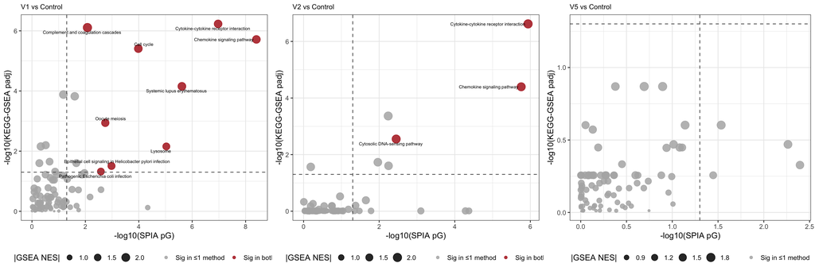

```r
plot_spia_gsea <- function(ck, title) {
  if (is.null(ck))
    return(ggplot() + theme_void() +
           ggtitle(paste(title, "\n(no SPIA results)")))
  d <- ck %>%
    dplyr::filter(!is.na(spia_pG) & !is.na(gsea_padj)) %>%
    dplyr::mutate(
      sig_spia = spia_pGFdr < 0.05,
      sig_gsea = gsea_padj  < 0.05,
      both     = sig_spia & sig_gsea,
      label    = ifelse(both, pathway_name, NA)
    )
  ggplot(d, aes(x = -log10(spia_pG), y = -log10(gsea_padj))) +
    geom_point(aes(color = both, size = abs(gsea_NES)), alpha = 0.85) +
    scale_color_manual(values = c(`TRUE` = "firebrick", `FALSE` = "gray70"),
                       labels = c("Sig in ≤1 method", "Sig in both"),
                       name = NULL) +
    geom_vline(xintercept = -log10(0.05), linetype = "dashed", color = "gray40") +
    geom_hline(yintercept = -log10(0.05), linetype = "dashed", color = "gray40") +
    geom_text_repel(aes(label = label), size = 2.5, max.overlaps = 25, na.rm = TRUE) +
    labs(title = title,
         x = "-log10(SPIA pG)", y = "-log10(KEGG-GSEA padj)",
         size = "|GSEA NES|") +
    theme(legend.position = "bottom",
          plot.title = element_text(size = 11))
}

grid.arrange(
  plot_spia_gsea(cross_kegg_list$V1, "V1 vs Control"),
  plot_spia_gsea(cross_kegg_list$V2, "V2 vs Control"),
  plot_spia_gsea(cross_kegg_list$V5, "V5 vs Control"),
  ncol = 3
)
```

A populated top-right corner at V1 means SPIA and KEGG-GSEA agree on the same database the V1 inflammatory signal is robust to method, not just topology-induced.

### 15.4.5 Bridge back to Hallmark, *gene-level* agreement at every visit

For each visit intersect the **leading-edge genes** of the top-5 Hallmark GSEA hits with the **member genes** of the top-5 SPIA KEGG pathways. High counts in red cells mean Hallmark and KEGG are describing the same gene populations.

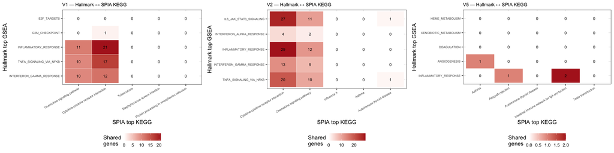

```r
hallmark_members_long <- msigdb_hallmark %>%
  dplyr::select(gs_name, gene_symbol)

build_overlap <- function(g_hallmark, ck) {
  df_h <- as.data.frame(g_hallmark)
  if (nrow(df_h) == 0 || is.null(ck)) return(NULL)
  top5_h <- df_h %>% dplyr::arrange(p.adjust) %>% head(5)
  if (nrow(top5_h) == 0) return(NULL)
  h_genes <- setNames(strsplit(top5_h$core_enrichment, "/"),
                      gsub("HALLMARK_", "", top5_h$ID))
  top5_s <- ck %>% dplyr::arrange(spia_pG) %>% head(5)
  if (nrow(top5_s) == 0) return(NULL)
  kegg_members <- split(msigdb_kegg$gene_symbol, msigdb_kegg$gs_name)
  s_genes <- lapply(top5_s$norm, function(n) {
    key <- paste0("KEGG_", n)
    if (key %in% names(kegg_members)) unique(kegg_members[[key]]) else character(0)
  })
  names(s_genes) <- top5_s$pathway_name
  m <- outer(seq_along(h_genes), seq_along(s_genes),
             Vectorize(function(i, j) {
               a <- h_genes[[i]]; b <- s_genes[[j]]
               if (length(a) == 0 || length(b) == 0) return(0)
               length(intersect(a, b))
             }))
  rownames(m) <- names(h_genes); colnames(m) <- names(s_genes)
  m
}

plot_overlap <- function(m, title) {
  if (is.null(m))
    return(ggplot() + theme_void() +
           ggtitle(paste(title, "\n(no top hits to compare)")))
  d <- as.data.frame(as.table(m))
  colnames(d) <- c("Hallmark", "SPIA_KEGG", "shared_genes")
  ggplot(d, aes(x = SPIA_KEGG, y = Hallmark, fill = shared_genes)) +
    geom_tile(color = "white") +
    geom_text(aes(label = shared_genes), size = 3.2) +
    scale_fill_gradient(low = "white", high = "firebrick") +
    labs(title = title,
         x = "SPIA top KEGG", y = "Hallmark top GSEA",
         fill = "Shared\ngenes") +
    theme(axis.text.x = element_text(angle = 30, hjust = 1, size = 7),
          axis.text.y = element_text(size = 7),
          plot.title  = element_text(size = 11),
          legend.position = "bottom")
}

m_v1 <- build_overlap(gsea_results$V1, cross_kegg_list$V1)
m_v2 <- build_overlap(gsea_results$V2, cross_kegg_list$V2)
m_v5 <- build_overlap(gsea_results$V5, cross_kegg_list$V5)

grid.arrange(
  plot_overlap(m_v1, "V1 — Hallmark ↔ SPIA KEGG"),
  plot_overlap(m_v2, "V2 — Hallmark ↔ SPIA KEGG"),
  plot_overlap(m_v5, "V5 — Hallmark ↔ SPIA KEGG"),
  ncol = 3
)
```

Saving the cross-database tables, for every visit

# 16. Results Interpretation & Discussion

This section brings together all findings into a coherent narrative.

## 16.1 What did we find? (The Big Picture)

```r
cat("DATA\n","  Genome reference: GRCh38.p13 (upgraded from hg19)\n"
,"  Aligner: Kallisto (upgraded from TopHat2/Cufflinks2)\n",
"  Samples analysed:", ncol(counts_filtered), "\n",
"  Genes after filtering:", nrow(counts_filtered), "\n\n",
"DIFFERENTIAL EXPRESSION (DESeq2, |lfc|>1, padj<0.05)\n")
```

```
## DATA
##    Genome reference: GRCh38.p13 (upgraded from hg19)
##    Aligner: Kallisto (upgraded from TopHat2/Cufflinks2)
##    Samples analysed: 75
##    Genes after filtering: 20374
##
##  DIFFERENTIAL EXPRESSION (DESeq2, |lfc|>1, padj<0.05)
```

```r
print(deg_summary)
```

```
##      Comparison Total  Up Down
## 1 V1 vs Control  1020 918  102
## 2 V2 vs Control   549 367  182
## 3 V5 vs Control   125  14  111
```

```r
cat("\nOriginal study (Limma/Voom on FPKM, |FC|>1.5, FDR<0.1%):\n",
"  V1: 1,235 DEGs | V2: 1,060 DEGs | V5: 686 DEGs\n\n",
"PATHWAY ANALYSIS (ORA + GSEA/GSVA + SPIA)\n",
"  1st gen ORA  (Hallmark, V1):", nrow(as.data.frame(ora_hallmark_v1)),
    "enriched pathways\n",
"  1st gen ORA  (GO:BP, V1):  ",
    sum(as.data.frame(ora_gobp_v1)$p.adjust < 0.05), "enriched terms\n")
```

```
##
## Original study (Limma/Voom on FPKM, |FC|>1.5, FDR<0.1%):
##    V1: 1,235 DEGs | V2: 1,060 DEGs | V5: 686 DEGs
##
##  PATHWAY ANALYSIS (ORA + GSEA/GSVA + SPIA)
##    1st gen ORA  (Hallmark, V1): 9 enriched pathways
##    1st gen ORA  (GO:BP, V1):   423 enriched terms
```

```r
cat("  2nd gen GSEA (Hallmark, V1):", sum(gsea_h_df$p.adjust < 0.05),
    "significant pathways\n",
"  2nd gen GSVA (Hallmark, V1):",
    sum(gsva_results_list$V1_vs_Ctrl$adj.P.Val < 0.05),
    "differentially active pathways\n")
```

```
##   2nd gen GSEA (Hallmark, V1): 6 significant pathways
##    2nd gen GSVA (Hallmark, V1): 43 differentially active pathways
```

```r
if (!is.null(spia_v1) && nrow(spia_v1) > 0) {
  cat("  3rd gen SPIA (KEGG, V1):    ",
      sum(spia_v1$pGFdr < 0.05, na.rm = TRUE),
      "pathways with pGFdr < 0.05\n")
} else {
  cat("  3rd gen SPIA (KEGG, V1):    not computed or empty\n")
}
```

```
##   3rd gen SPIA (KEGG, V1):     34 pathways with pGFdr < 0.05
```

## 16.2 Biological Interpretation

### The Acute Phase (V1): A Strong Inflammatory Storm

- **TNFA signaling via NF-κB** , *master pro-inflammatory programme*. The full mechanism (TNF-α → TNFR1 → IKK → NF-κB → autocrine cytokine loop), the leading-edge gene table, and the cytokine glossary are detailed in **Section 11.2.1**. Original paper also called out TNF-α as a top upstream regulator.
- **Interferon-γ response** , IFN-γ from T cells and NK cells activates macrophages and drives Th1 immunity (the lineage required against spirochetal pathogens). Matches the original study’s TREM1-mediated Th1 activation finding. The core ISGs *ISG15 / IFI27 / BATF2* (highlighted in **Section 10.6**) explain why this Hallmark scores so high.
- **Inflammatory response** , broad cytokine, chemokine, and leukocyte-recruitment programme; expected hallmark of an acute bacterial infection.
- **Complement** , ancient innate defence that lyses bacteria and tags them for phagocytosis. *SERPING1* (a complement regulator highlighted in 10.6) sits in the leading edge.
- **IL6–JAK–STAT3 signaling** , IL-6 drives the acute-phase response (CRP, fever); identified as a top upstream regulator at V1 and V2 in the original paper.

The gene-level story (**Section 10.6**) maps cleanly onto these pathway-level themes:

- **Pathogen sensing.** *TLR2* (Section 10.6, pick #4) is the direct *B. burgdorferi* lipoprotein receptor , the molecular entry point that lights up the entire downstream NF-κB / IFN-γ programme described above.
- **Innate effector activation.** *S100A8 / S100A9* (calprotectin, pick #2) and *FCGR1A* (CD64, pick #3) reflect massive neutrophil + monocyte activation, which is what the *Inflammatory Response* and *Complement* Hallmarks summarise at the gene-set level.
- **Persistent biomarker.** *CXCL10* (pick #1) is the single most cited Lyme/PTLDS biomarker; its strong V1 induction is the gene-level driver of *Interferon-γ Response* and *IL6-JAK-STAT3*, and it carries forward into V2/V5 (see below).
- **Resolution / exhaustion machinery already engaged.** *IDO1* (pick #5) and *CD274 / PD-L1* (pick #6) are induced even at V1, hinting that the host is already activating immunoregulatory brakes , relevant for why the signature later fails to fully resolve.

**SPIA (Section 15)** adds the topology-aware view: pathways where both list enrichment *and* signed graph perturbation suggest activation/inhibition (e.g. chemokine signalling, lysosome, cell-cycle KEGG maps). Treat as complementary to Hallmark/GO, not a one-to-one match.

### Post-Treatment (V2): The Signature Persists

At V2 (3 weeks later, after completing antibiotics) a substantial number of DEGs and Hallmark pathways remain active , the paper’s central finding: **the gene-expression signature does not promptly return to baseline after treatment**, unlike most other acute infections.

### Six Months Later (V5): Partial but Incomplete Recovery

If we wanted *one gene to track* across V1 → V2 → V5 in a future serum-based clinical follow-up, **CXCL10 (pick #1 in Section 10.6)** is the strongest candidate, with prior independent validation as a PTLDS biomarker (Soloski et al. 2014, Aucott et al. 2016).

## 17.3 Answering Open Questions from the Analysis

**Section 5.2, “Is the mean set correctly for the mean-variance plot?”** Yes. The plot correctly shows that for raw RNA-Seq counts, the variance consistently exceeds the mean (overdispersion). The red Poisson line (variance = mean) is a theoretical baseline. The fact that points sit above it is not an error; it is the fundamental property of count data that justifies using the negative binomial model in DESeq2.

**Section 7.4, “VST doesn’t seem to flatten the mean-SD relationship?”** The VST does reduce the dependency, even if visually the “before” and “after” plots look similar. The key metric is the correlation between mean and SD: even a modest reduction (e.g., from 0.8 to 0.5) meaningfully improves downstream analyses like PCA. The fact that the correlation doesn’t drop to zero is normal – VST is an approximation, not magic. For small sample sizes, `rlog()` (regularised log) can perform better than VST but is much slower. Both are acceptable for this project.

**MA plots (Sections 5.3, 7.3, 10.1b) , do they validate normalization?**  
Section 5.3 uses raw log2 counts: systematic offset is expected. Section 7.3 uses **size-factor–normalized** counts only; the loess trend should sit closer to **M = 0**. Section **10.1b** uses **DESeq2**’s `plotMA()` after dispersion shrinkage: the central mass of points at moderate-to-high expression should lie near **LFC = 0** for non-DEGs (blue = padj < alpha). Together, these three plots answer “did we fix depth?” vs “what does the fitted model say about differential expression?”

**Section 12.2, “Which pathways should we expect activated/suppressed?”** Based on what we know about Lyme disease biology:

*Expected activated:* Inflammatory response, TNF-alpha signaling, interferon signaling (IFN-gamma, IFN-alpha), complement, IL6-JAK-STAT, TLR signaling, NF-kB signaling, apoptosis.

*Potentially suppressed:* The original paper found eIF2 signaling (translation initiation) downregulated at all time points. In our GSEA results, look for pathways with negative NES (blue in the heatmap). Suppressed MYC targets or mTORC1 signaling would indicate reduced cell growth/proliferation, consistent with immune cells diverting resources from growth to defence.